# California House Price Prediction

- **Author**: [Andy Wang](https://www.linkedin.com/in/andy-wang-3b595a299/), Johns Hopkins University, Class of 2027
- **Github Repository**: https://github.com/sirandy3000/projects/tree/master/housing

## Abstract

> This Jupyter notebook contains my solution to a classic introductory machine learning problem: to predict the median house price of 20640 California districts. The features (median income, population, location, etc.) were obtained as part of the 1990 US census. To solve this problem, I first performed Exploratory Data Analysis, considering each feature's distribution and correlation with median house price, to better understand the possible insights that each feature could provide. I then engineered and transformed features using techniques such as K-Means clustering and Nearest-Neighbors imputation. Finally, I performed cross-validation on several models and fine-tuned the hyperparameters of the best performer.

## Contents

1. Project Setup
2. Exploratory Data Analysis
3. Data Preprocessing
4. Modeling
5. Evaluation

## 1. Project Setup

In this section, I import required packages and download the dataset.

### 1.1) Package Import

```python
import os
import urllib
import tarfile

import numpy as np
import pandas as pd
import matplotlib.pyplot as plt
```

```python
from sklearn.base import BaseEstimator, TransformerMixin
from sklearn.cluster import KMeans
from sklearn.compose import ColumnTransformer
from sklearn.ensemble import GradientBoostingRegressor, RandomForestRegressor

from sklearn.impute import KNNImputer
from sklearn.linear_model import LinearRegression, Ridge, Lasso
from sklearn.metrics import root_mean_squared_error
from sklearn.metrics.pairwise import rbf_kernel

from sklearn.model_selection import cross_val_score, RandomizedSearchCV, train_test_split
from sklearn.pipeline import make_pipeline, Pipeline
from sklearn.preprocessing import FunctionTransformer, OneHotEncoder, StandardScaler
from sklearn.svm import SVR
```

### 1.2) Data Download

I download the dataset from Github user ageron's data repository. The dataset arrives as a Tarfile, from which I extract a CSV containing the housing records.

```python
def download_housing_data():
    url = "https://github.com/ageron/data/raw/main/housing.tgz"
    dest = "housing.tgz"
    urllib.request.urlretrieve(url, dest)
    with tarfile.open(dest) as tarball:
        tarball.extractall(path=".")
    os.rename(os.path.join("housing", "housing.csv"), "housing.csv")
    os.rmdir("housing")
    os.remove(dest)

def load_housing_data():
    return pd.read_csv("housing.csv")
```

```python
download_housing_data()
housing = load_housing_data()
```

## 2. Exploratory Data Analysis

In this section, I explore the dataset, including:

- The number of features and instances
- The distribution of each feature
- Possible ways to engineer better features
- Correlation between each feature and the target

### 2.1) Dataset Information

The dataset contains 20640 instances (one for each district), 9 features (8 quantitative and 1 categorical), and the target variable `median_house_value`.

```python
housing.info()
```

```
<class 'pandas.core.frame.DataFrame'>
RangeIndex: 20640 entries, 0 to 20639
Data columns (total 10 columns):
 #   Column              Non-Null Count  Dtype
---  ------              --------------  -----
 0   longitude           20640 non-null  float64
 1   latitude            20640 non-null  float64
 2   housing_median_age  20640 non-null  float64
 3   total_rooms         20640 non-null  float64
 4   total_bedrooms      20433 non-null  float64
 5   population          20640 non-null  float64
 6   households          20640 non-null  float64
 7   median_income       20640 non-null  float64
 8   median_house_value  20640 non-null  float64
 9   ocean_proximity     20640 non-null  object
dtypes: float64(9), object(1)
memory usage: 1.6+ MB
```

### 2.2) Feature Distributions

All features besides `ocean_proximity` are quantitative; visualization reveals that many have positively skewed distributions.

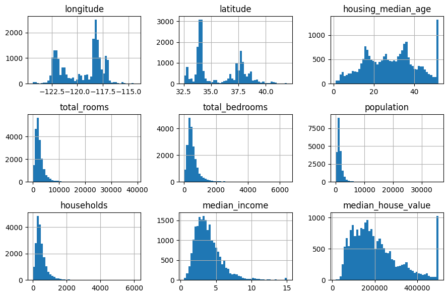

```python
housing.hist(bins=50, figsize=(9, 6))
plt.tight_layout()
plt.show()
```

`ocean_proximity`, meanwhile, is an arbitrary designation of how far each district is from the ocean/bay.

```python
housing.ocean_proximity.value_counts()
```

```
ocean_proximity
<1H OCEAN     9136
INLAND        6551
NEAR OCEAN    2658
NEAR BAY      2290
ISLAND           5
Name: count, dtype: int64
```

### 2.3) Geographic Information

Plotting latitude vs longitude reveals the geographic location of each district.

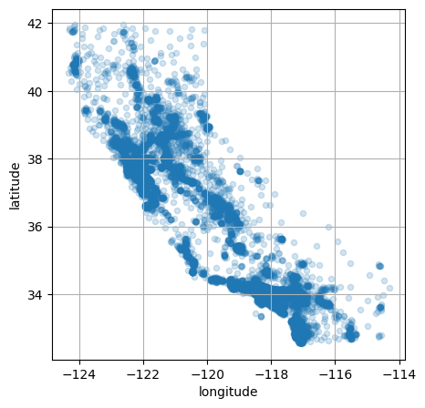

```python
housing.plot(kind="scatter", x="longitude", y="latitude",
             figsize=(5, 5), alpha=0.2, grid=True)
plt.show()
```

Plotting the geographic locations along with the target variable reveals that expensive districts tend to surround San Francisco and Los Angeles, i.e. that urban districts have more expensive houses. Later, I transform latitude and longitude into a measure of "urban-ness" to make this insight usable in my models.

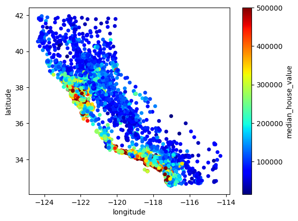

```python
housing.plot(kind="scatter", x="longitude", y="latitude",
    c="median_house_value", cmap="jet", colorbar=True)
plt.show()
```

### 2.4) Correlation

Before feature engineering, `median_income` is by far the feature most correlated with `median_house_value`.

```python
correlation = housing.select_dtypes("float64").corr()
correlation.median_house_value.sort_values(ascending=False)
```

```
median_house_value    1.000000
median_income         0.688075
total_rooms           0.134153
housing_median_age    0.105623
households            0.065843
total_bedrooms        0.049686
population           -0.024650
longitude            -0.045967
latitude             -0.144160
Name: median_house_value, dtype: float64
```

## 3. Data Preprocessing

In this section, I preprocess the dataset, including:

- Removing duplicate entries
- Splitting data into training and evaluation sets
- Normalizing features with skewed distributions
- Engineering new features
- Imputing, encoding, scaling

### 3.1) Duplicate Entries

The dataset contains no duplicate entries to remove.

```python
housing.duplicated().sum()
```

```
0
```

### 3.2) Train-Test Splitting

Before any further preprocessing, I split the dataset into a training set and an evaluation set. Given that `median_income` is highly correlated with `median_house_value`, I wanted both sets to have similar `median_income` distributions, which I achieved by stratifying the split on a discrete (binned) version of the feature. I allocated 80% of the dataset for training, leaving 20% for evaluation.

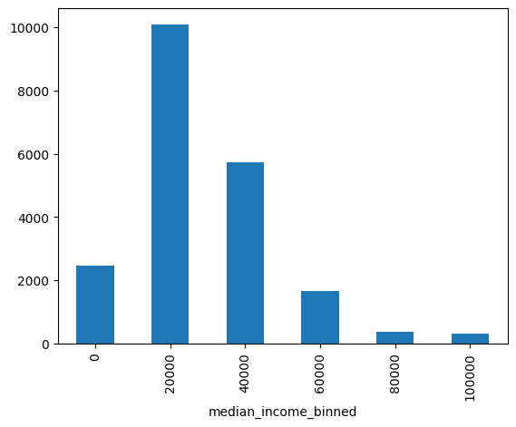

```python
housing["median_income_binned"] = pd.cut(
    housing.median_income,
    bins = np.append(np.arange(0, 12, 2), np.inf),
    labels = np.arange(0, 12, 2) * 10000
)
housing.median_income_binned.value_counts().sort_index().plot(kind="bar")
plt.show()
```

```python
X = housing[[c for c in housing.columns if c != "median_house_value"]]
y = housing.median_house_value

X_train, X_test, y_train, y_test = train_test_split(
    X, y, test_size=0.2, random_state=42,
    stratify=housing.median_income_binned
)
X_train.drop("median_income_binned", axis=1, inplace=True)
X_test.drop( "median_income_binned", axis=1, inplace=True)
```

### 3.3) Normalization

As shown in section (2.2), features `total_rooms`, `total_bedrooms`, `households`, `population`, and `median_income` are all positive and positively skewed, making their logarithms approximately normal. Thus, I train my models on their logarithms using a Function Transformer.

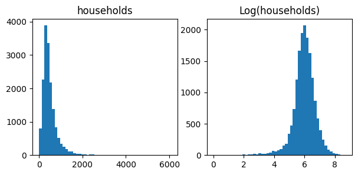

```python
log_fig, log_axs = plt.subplots(ncols=2, figsize=(7, 3))
log_axs[0].hist(X_train.households, bins=50)
log_axs[1].hist(np.log(X_train.households), bins=50)

log_axs[0].set(title="households")
log_axs[1].set(title="Log(households)")
plt.show()
```

```python
def log_name(function_transformer, feature_names_in):
    return ["log_"] + feature_names_in

log_transformer = FunctionTransformer(np.log, feature_names_out=log_name)
```

### 3.4) Feature Engineering

I wanted to create a measure of "urban-ness" using latitude and longitude, and initially thought the best way to achieve this was to measure the distances between each district and its nearest neighbors. I used `KNeighborsClassifier().kneighbors()` to calculate these distances, but found that urban and rural districts yielded similar results.

I then realized I could measure the distances between each district and the urban centers (i.e. San Francisco and Los Angeles) as "urban-ness". I could cluster the districts using `KMeans`, using each cluster center as an urban center, and the distances and new features. I chose RBF similarity as the distance metric, as Euclidean distance again yielded similar results for all districts.

```python
class UrbanDistance(BaseEstimator, TransformerMixin):
    def __init__(self, k=5, gamma=1, random_state=42):
        self.k = k
        self.gamma = gamma
        self.random_state = random_state
    def fit(self, X, y=None):
        self.kmeans = KMeans(self.k, random_state=self.random_state)
        self.kmeans.fit(X)
        return self
    def transform(self, X):
        return rbf_kernel(X, self.kmeans.cluster_centers_, gamma=self.gamma)
    def get_feature_names_out(self, feature_names_in=None):
        return [f"center_{i}_distance" for i in range(self.k)]
```

```python
ud = UrbanDistance()
distances = ud.fit_transform(X_train[["longitude", "latitude"]])
nearest_cluster_distance = distances.max(axis=1)
```

Visualization of the distances between each district and its nearest urban center reveals the desired measure of "urban-ness". The final number of urban centers is a hyperparameter tuned in section (4.2).

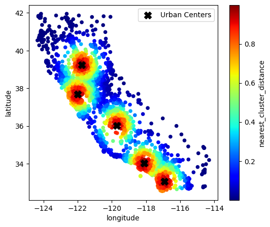

```python
ud_fig, ud_axs = plt.subplots(figsize=(6, 5))

X_train.plot(
    kind="scatter", x="longitude", y="latitude",
    c=nearest_cluster_distance, cmap="jet",
    colorbar=True, ax=ud_axs
)
centers = ud.kmeans.cluster_centers_
ud_axs.scatter(
    centers[:, 0], centers[:, 1], color="k",
    marker="X", s=100, label="Urban Centers"
)
ud_fig.axes[1].set(ylabel="nearest_cluster_distance")
ud_axs.legend()
plt.show()
```

### 3.5) Final Steps

The final preprocessing steps are to impute missing values, encode categorical features, and scale quantitative features. Feature `total_bedrooms` contains missing values, for which I used nearest-neighbor imputation, as districts with similar `total_rooms`, `population`, and `households` likely have similar `total_bedrooms`. The values of `ocean_proximity`, listed in section (2.2), have no innate ordering, so I used one-hot encoding. Finally, I assembled all steps into a single transformer.

```python
log_features = ["housing_median_age", "total_rooms", "total_bedrooms",
                "population", "households", "median_income",]
geo_features = ["longitude", "latitude"]
cat_features = ["ocean_proximity"]
```

```python
log_pipe = make_pipeline(
    KNNImputer(),
    log_transformer,
    StandardScaler()
)
geo_pipe = make_pipeline(
    UrbanDistance(),
    StandardScaler()
)
cat_pipe = make_pipeline(
    OneHotEncoder(sparse_output=False)
)
```

```python
preprocessing = ColumnTransformer([
    ("log", log_pipe, log_features),
    ("geo", geo_pipe, geo_features),
    ("cat", cat_pipe, cat_features)
])
X_train_preprocessed = preprocessing.fit_transform(X_train)
```

## 4. Modeling

In this section, I trained several models, then tuned the hyperparameters of the best-performing model.

### 4.1) Initial Models

Using 5-fold cross-validation, I first trained and evaluated several models, listed below, with default parameters. The best-performing model, i.e. that with the lowest mean RMSE, was Random Forest Regression.

```python
models = {
    "Linear":         LinearRegression(),
    "Ridge":          Ridge(random_state=42),
    "Lasso":          Lasso(random_state=42),
    "SVR_linear":     SVR(kernel="linear"),
    "SVR_poly":       SVR(kernel="poly"),
    "SVR_rbf":        SVR(kernel="rbf"),
    "SVR_sigmoid":    SVR(kernel="sigmoid"),
    "Random_Forest":  RandomForestRegressor(random_state=42),
    "Gradient_Boost": GradientBoostingRegressor(random_state=42)
}
```

```python
cv_scores = []
for name, model in models.items():
    cvs = cross_val_score(
        model, X_train_preprocessed, y_train, cv=5, n_jobs=-1,
        scoring="neg_root_mean_squared_error"
    )
    cv_scores.append([name, -cvs.mean(), cvs.std()])
```

```python
cv_scores = pd.DataFrame(cv_scores, columns=["model", "mean_rmse", "std_rmse"])
cv_scores = cv_scores.sort_values("mean_rmse").reset_index(drop=True)
cv_scores
```

|  | model | mean_rmse | std_rmse |
| --- | --- | --- | --- |
| 0 | Random_Forest | 49633.527428 | 1312.165709 |
| 1 | Gradient_Boost | 55475.223462 | 1886.310113 |
| 2 | Lasso | 71151.337171 | 1731.588120 |
| 3 | Linear | 71151.922054 | 1732.792685 |
| 4 | Ridge | 71154.373029 | 1731.737756 |
| 5 | SVR_linear | 111311.241282 | 1697.682372 |
| 6 | SVR_poly | 117800.252829 | 1583.871544 |
| 7 | SVR_sigmoid | 117808.862009 | 1599.796858 |
| 8 | SVR_rbf | 118080.001550 | 1589.754301 |

### 4.2) Hyperparameter Tuning

Using randomized search, I tuned:

- The maximum depth of the Decision Trees
- The number of features to consider when splitting each Decision Tree node
- The number of urban centers in the UrbanDistance transformer
- The number of neighbors in the KNNImputer

```python
pipeline = Pipeline([
    ("preprocessing", preprocessing),
    ("model", RandomForestRegressor(random_state=42))
])
parameters = {
    "model__max_depth": np.arange(4, 44, 4),
    "model__max_features": np.arange(2, 22, 2),
    "preprocessing__geo__urbandistance__k": np.arange(10, 110, 10),
    "preprocessing__log__knnimputer__n_neighbors": np.arange(5, 55, 5)
}
```

```python
random_search = RandomizedSearchCV(
    pipeline, parameters, n_iter=100, cv=3, n_jobs=-1,
    scoring="neg_root_mean_squared_error", random_state=42
)
random_search.fit(X_train, y_train)
```

```
RandomizedSearchCV(cv=3,
                   estimator=Pipeline(steps=[('preprocessing',
                                              ColumnTransformer(transformers=[('log',
                                                                               Pipeline(steps=[('knnimputer',
                                                                                                KNNImputer()),
                                                                                               ('functiontransformer',
                                                                                                FunctionTransformer(feature_names_out=<function log_name at 0x7fe164bb2a20>,
                                                                                                                    func=<ufunc 'log'>)),
                                                                                               ('standardscaler',
                                                                                                StandardScaler())]),
                                                                               ['housing_median_age',
                                                                                'total_rooms',
                                                                                'total_bed...
                   param_distributions={'model__max_depth': array([ 4,  8, 12, 16, 20, 24, 28, 32, 36, 40]),
                                        'model__max_features': array([ 2,  4,  6,  8, 10, 12, 14, 16, 18, 20]),
                                        'preprocessing__geo__urbandistance__k': array([ 10,  20,  30,  40,  50,  60,  70,  80,  90, 100]),
                                        'preprocessing__log__knnimputer__n_neighbors': array([ 5, 10, 15, 20, 25, 30, 35, 40, 45, 50])},
                   random_state=42, scoring='neg_root_mean_squared_error')
```

```python
old_rmse = cv_scores.loc[0, "mean_rmse"]
new_rmse = -random_search.best_score_
reduction = (old_rmse - new_rmse) / old_rmse

print(f"RMSE before tuning: {old_rmse:.0f}")
print(f"RMSE after tuning: {new_rmse:.0f}")
print(f"RMSE reduced by: {reduction:.3%}")
```

```
RMSE before tuning: 49634
RMSE after tuning: 43750
RMSE reduced by: 11.855%
```

```python
final_model = random_search.best_estimator_
random_search.best_params_
```

```
{'preprocessing__log__knnimputer__n_neighbors': 45,
 'preprocessing__geo__urbandistance__k': 60,
 'model__max_features': 14,
 'model__max_depth': 20}
```

## 5. Evaluation

In this section, I evaluated the final model on the evaluation set, then analyzed the importances of several features in making predictions.

### 5.1) Generalization Error

The model performed slightly better on the evaluation set than on the validation folds, indicating that it generalizes well and did not overfit.

```python
y_pred = final_model.predict(X_test)
final_rmse = root_mean_squared_error(y_test, y_pred)
gen_error = (new_rmse - final_rmse) / new_rmse

print(f"RMSE on evaluation set: {final_rmse:.0f}")
print(f"The final model performed {gen_error:.3%} better on the evaluation set.")
```

```
RMSE on evaluation set: 43375
The final model performed 0.857% better on the evaluation set.
```

### 5.2) Feature Importances

The most important features in predicting `median_house_value` are median income, whether the district is `INLAND`, and the district's distances to the urban centers. Median income is sensible, as wealthier people tend to buy more expensive houses; "inland-ness" is surprising, however, and is worth further investigation in future analyses.

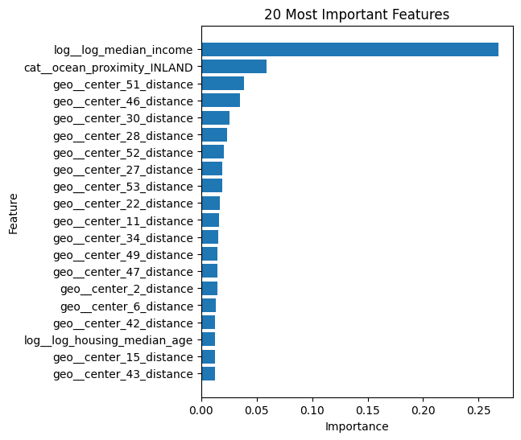

```python
fig, axs = plt.subplots(figsize=(5, 6))

feature_importances = zip(
    final_model[0].get_feature_names_out(),
    final_model[1].feature_importances_
)
features, importances = zip(*sorted(feature_importances, key=lambda x: x[1]))

axs.barh(features[-20:], importances[-20:])
axs.set(title="20 Most Important Features", xlabel="Importance", ylabel="Feature")
plt.show()
```